# Final Report

Aidan O’Hara

2022-12-11

## Introduction

Summer’s warm weather and rainy climate brings on the perfect opportunity for humanity’s ultimate nemesis to make itself known: Mosquitoes. This [Mosquito Dataset](https://www.kaggle.com/datasets/chicago/chicago-west-nile-virus-mosquito-test-results/metadata), found originally on Kaggle, originally from https://data.cityofchicago.org/, contains records about trapped mosquitoes, their response to a West Nile Virus test, and the location of the trap, for seasonal weeks between 2007 and 2022. Mosquitoes while highly adaptable still require specific circumstances to propagate, standing water sources, food sources (us), and other environmental factors. As one such food source, investigation of demographic predictors seemed appealing.

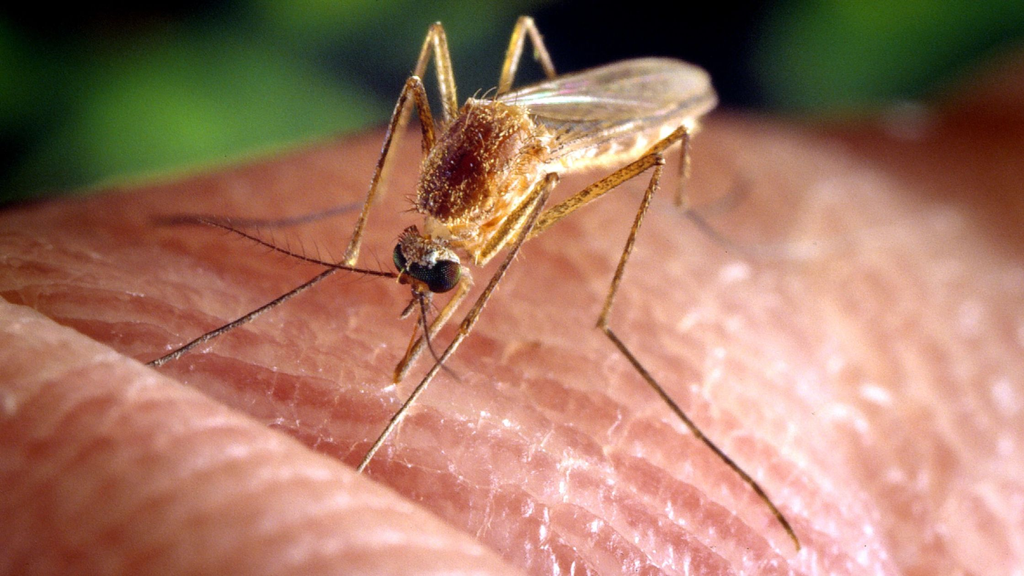

For emotional impact.

Joining the Mosquito data with geographic and demographic information from the American Community Survey the following analysis inquires whether local median income and population density influence the number of trapped mosquitoes.

## Method

The data is formatted such that each row reports the number of collected mosquitoes, of a specific species, where the sample was collected, and the result of the West Nile Virus test. To keep things straightforward regarding time, only data from 2015 will be used.

```r
head(quito15[,c(4,8:12)],n =3)
```

|  | BLOCK | NUMBER.OF.MOSQUITOES | RESULT | SPECIES | LATITUDE | LONGITUDE |
| --- | --- | --- | --- | --- | --- | --- |
| 1 | 25XX S MILLARD AVE | 1 | negative | CULEX PIPIENS | 41.84572 | -87.71590 |
| 2 | 63XX W 64TH ST | 4 | negative | CULEX RESTUANS | 41.77601 | -87.77941 |
| 3 | 9XX W GARFIELD BLVD | 3 | negative | CULEX RESTUANS | 41.79437 | -87.64893 |

Next, median income and population are collected from the American Community Survey at the tract level within Cook County Illinois. After some cleaning, population density is calculated using the included shape files.

```r
disChicago <- st_drop_geometry(chicagoBetter)
head(disChicago[,c(2:6)],n =3)
```

| NAME | population | medincome | area | density |
| --- | --- | --- | --- | --- |
| Census Tract 107.02 | 5163 | 957 | 0.355592611 [km^2] | 14519.42 [1/km^2] |
| Census Tract 301.01 | 3613 | 994 | 0.123709249 [km^2] | 29205.58 [1/km^2] |
| Census Tract 307.02 | 1457 | 1037 | 0.004233461 [km^2] | 344162.82 [1/km^2] |

By joining the two tables using their included geometry, each mosquito trap is associated with its specific Census Tract and better still, the ACS estimates about the Census Tract in 2015.

Summarizing the resulting join by the Census Tracts, result of the West Nile Virus test, and the week of each given observation results in a table that provides the total captured mosquitoes by week, by Census Tract, and positivity.

Now each observation has:

```r
disWeeks <- select(perWeeks, -geometry)
head(disWeeks[,c(1:2,4:10)],n =3)
```

| NAME | WEEK | population | medincome | area | density | negative | positive | totalMosq |
| --- | --- | --- | --- | --- | --- | --- | --- | --- |
| Census Tract 1007 | 23 | 4788 | 1267 | 1.213696 [km^2] | 3944.976 [1/km^2] | 12 | 0 | 12 |
| Census Tract 1007 | 24 | 4788 | 1267 | 1.213696 [km^2] | 3944.976 [1/km^2] | 16 | 0 | 16 |
| Census Tract 1007 | 25 | 4788 | 1267 | 1.213696 [km^2] | 3944.976 [1/km^2] | 8 | 0 | 8 |

Using the Minnesota Radon example as a guide: The density of trapped mosquitoes in each Census Tract is displayed below. Applying a log transform to the totals for clarity of distribution.

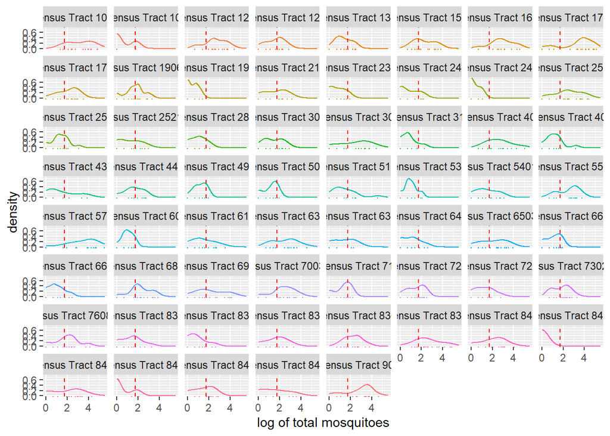

Important to this analysis, there is clear differentiation of which Census Tract the mosquitoes are collected from.

## Result

Fitting a Multi-Level-Linear-Model,

`totalMosq ~ log(density) + log(medincome) + (1|NAME)`

provided less than desired results. Instead, this analysis will fit seperate models for population density and median income.

```r
summary(lmer_fit2)
```

```
## Linear mixed model fit by REML ['lmerMod']
## Formula: totalMosq ~ log(medincome) + (1 | NAME)
##    Data: perWeeks
##
## REML criterion at convergence: 7279.5
##
## Scaled residuals:
##     Min      1Q  Median      3Q     Max
## -2.6893 -0.3369 -0.1532  0.0836 10.0831
##
## Random effects:
##  Groups   Name        Variance Std.Dev.
##  NAME     (Intercept) 128.7    11.35
##  Residual             362.0    19.03
## Number of obs: 823, groups:  NAME, 61
##
## Fixed effects:
##                Estimate Std. Error t value
## (Intercept)    12.29695   40.77435   0.302
## log(medincome) -0.02991    5.84735  -0.005
##
## Correlation of Fixed Effects:
##             (Intr)
## log(medncm) -0.999
```

Here, the fixed effect intercept of `12.3` represents the overall average number of mosquitoes caught each week, regardless of Census Tract. This model suggests that increases of the median income log-factor does decrease the caught mosquitoes by a small amount.

```r
summary(lmer_fit3)
```

```
## Linear mixed model fit by REML ['lmerMod']
## Formula: totalMosq ~ log(density) + (1 | NAME)
##    Data: perWeeks
##
## REML criterion at convergence: 7280.8
##
## Scaled residuals:
##     Min      1Q  Median      3Q     Max
## -2.6744 -0.3465 -0.1532  0.0804 10.0988
##
## Random effects:
##  Groups   Name        Variance Std.Dev.
##  NAME     (Intercept) 126.8    11.26
##  Residual             361.9    19.02
## Number of obs: 823, groups:  NAME, 61
##
## Fixed effects:
##              Estimate Std. Error t value
## (Intercept)    26.866     16.237   1.655
## log(density)   -1.833      2.005  -0.914
##
## Correlation of Fixed Effects:
##             (Intr)
## log(densty) -0.995
```

The following plots offer some interpretation of the Census Tract effects.

Median Income:

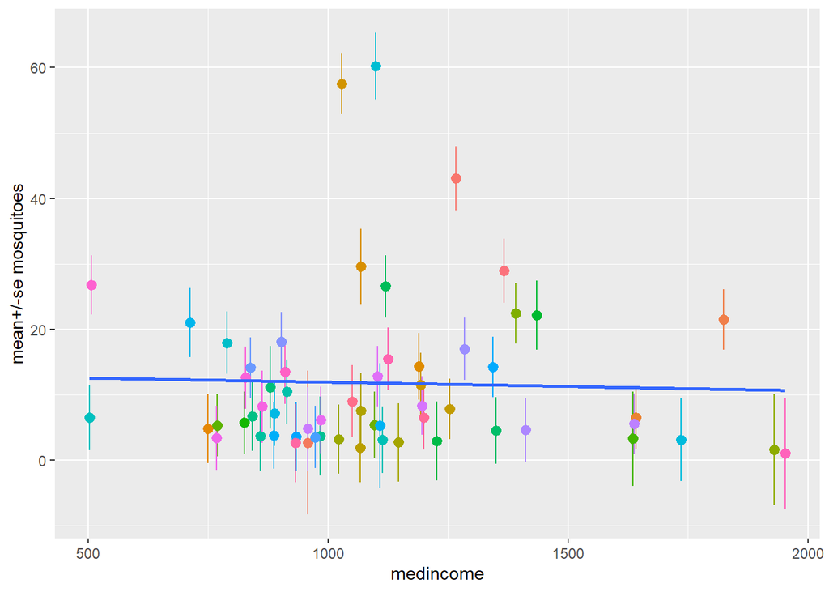

and population density:

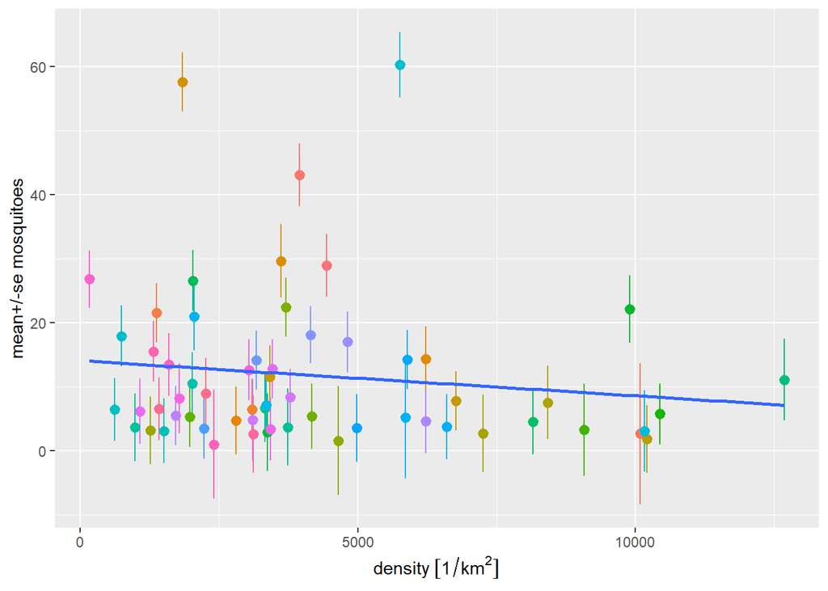

Both plots reflect the model findings, that increase in median income and population density incur a reduction in the number of caught mosquitoes. Remember though, increased population density should be more favorable to mosquitoes.

## Discussion

This analysis could absolutely be improved with any of the following:

- Considerations for the broader collection of Census Tracts around each trap site.
- Inclusion of more interesting American Community Survey variables
- Analysis of the results of the West Nile Virus Test
- Categorical analysis of the various Species of captured Mosquitoes.
- and much more.